# Analyzing Animal Crossing Data

Tidy Tuesday - 05/05/20

Omar Lopez Rubio

This week Tidy Tuesday has bring some data from the last Animal Crossing game.

```r
library(tidyverse)
knitr::opts_chunk$set(echo = TRUE, fig.align="center")
knitr::opts_chunk$set(fig.width=12, fig.height=8)


critic <- readr::read_tsv('https://raw.githubusercontent.com/rfordatascience/tidytuesday/master/data/2020/2020-05-05/critic.tsv')
user_reviews <- readr::read_tsv('https://raw.githubusercontent.com/rfordatascience/tidytuesday/master/data/2020/2020-05-05/user_reviews.tsv')
items <- readr::read_csv('https://raw.githubusercontent.com/rfordatascience/tidytuesday/master/data/2020/2020-05-05/items.csv')
```

First of all I’m going to check the *critics* data.

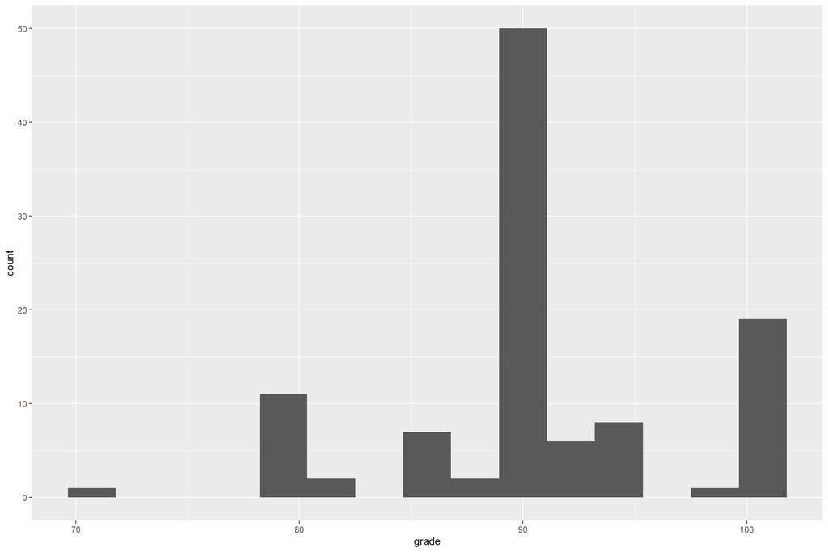

```r
critic %>%
  ggplot(aes(x = grade)) + geom_histogram(bins = 15)
```

```r
critic %>%
  filter(str_length(text) == max(str_length(text))) %>%
  pull(text)
```

```
## [1] "Animal Crossing: New Horizons takes Animal Crossing and not only drags it back onto home consoles, but improves upon every single facet imaginable. There's more to do, more to see, more to change, more to mould, and more to love; fans and first-time players are going to find themselves losin…
```

Critic consists basically in a website name, a grade, a text review and a date. The grades are around 90 (0-100). The *text* column gives us a brief resum of the author’s opinon about the game. It seems like a good opportinuty to use *tidytext*, don’t agree? So let’s do some sentiment analysis with the *afinn* sentiment dataset.

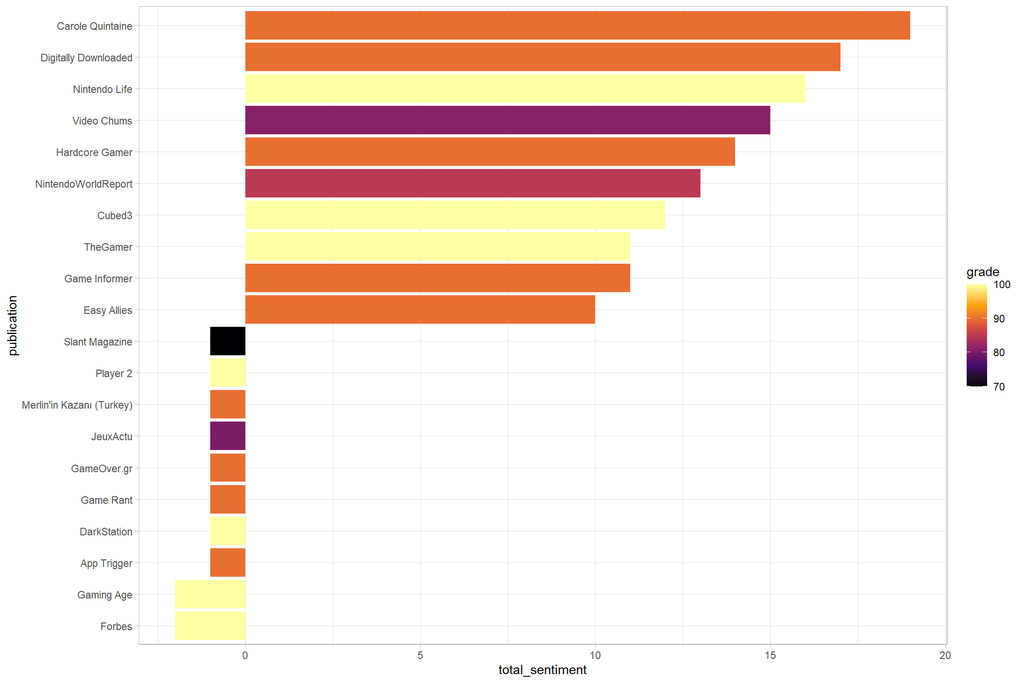

```r
library(tidytext)
critic_tokens <- critic %>%
  mutate(id = row_number()) %>%
  unnest_tokens(word, text)

critic_w_sentiments <- critic_tokens %>%
  filter(!word %in% stop_words$word) %>%
  inner_join(get_sentiments("afinn")) %>%
  group_by(publication) %>%
  summarize(total_sentiment = sum(value)) %>%
  inner_join(critic) %>%
  mutate(publication = as_factor(publication),
         publication = fct_reorder(publication, total_sentiment))


critic_w_sentiments %>%
  arrange(desc(total_sentiment)) %>%
  slice(c(head(row_number(), 10), tail(row_number(), 10))) %>%
  ggplot(aes(x = publication, y = total_sentiment, fill = grade)) +
  geom_col() +
  coord_flip() + scale_fill_viridis_c(option = "inferno") + theme_light()
```

I like this plot. It shows us 20 reviews, the top 10 with highest *total_sentiment* and the bottom 10. Also it shows the *grade*, that is, the score given to the game. As we can see the reviews are positive, with a minimum at about 70. There is somehow a publication where the *total_sentiment* is negative. Let’s check them out.

```r
critic_w_sentiments %>%
  arrange(desc(total_sentiment)) %>%
  slice(tail(row_number(), 2))
```

```
## # A tibble: 2 x 5
##   publication total_sentiment grade text                              date
##   <fct>                 <dbl> <dbl> <chr>                             <date>
## 1 Forbes                   -2   100 Know that if you’re overwhelmed ~ 2020-03-16
## 2 Gaming Age               -2   100 Being able to play the game with~ 2020-04-02
```

```r
critic_w_sentiments %>%
  arrange(desc(total_sentiment)) %>%
  slice(tail(row_number(), 2)) %>%
  head(2) %>%
  pull(text)
```

```
## [1] "Know that if you’re overwhelmed with the world, stuck inside, or adrift in a life that you know will look totally different next week — get Animal Crossing."
## [2] "Being able to play the game with family in the same household may require a bit much (multiple Switch consoles and copies of the game) but when you get it all up and running, it is a great way to spend your time stuck at home. I’ve spent hours with the game every day since launch, and have y…
```

Our simple approach cannot tell the underlaying meaning in some of these phrases. For instance, the first text is telling us a lot of “bad” words, and later it negates them to refeer to the game. I had to try it!

```r
critic_w_sentiments %>%
  summarize(sd = sd(grade),
            mean = mean(grade))
```

```
## # A tibble: 1 x 2
##      sd  mean
##   <dbl> <dbl>
## 1  6.23  90.9
```

So yeah, small standard deviation and a mean of 90.91, so overall really good critics from the media.

Let’s talk about the users. The users are not as polite as the media, and the opinions we’re going to get are probably going to be more biased in personal experiences or moments than in the game itself.

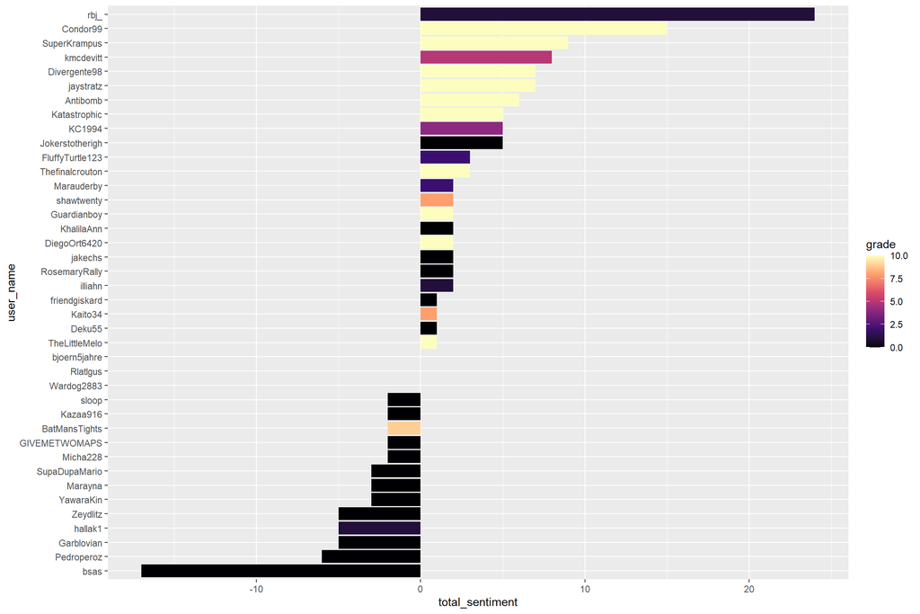

```r
user_reviews_tokens <- user_reviews %>%
  unnest_tokens(word, text)

user_w_sentiments <- user_reviews_tokens %>%
  filter(!word %in% stop_words$word) %>%
  inner_join(get_sentiments("afinn")) %>%
  group_by(user_name) %>%
  summarize(total_sentiment = sum(value)) %>%
  inner_join(user_reviews)

set.seed(42)
user_w_sentiments %>%
  sample_n(40) %>%
  mutate(user_name = as_factor(user_name),
         user_name = fct_reorder(user_name, total_sentiment)) %>%
  ggplot(aes(x = user_name, y = total_sentiment, fill = grade)) + geom_col() +
  coord_flip() + scale_fill_viridis_c(option = "magma")
```

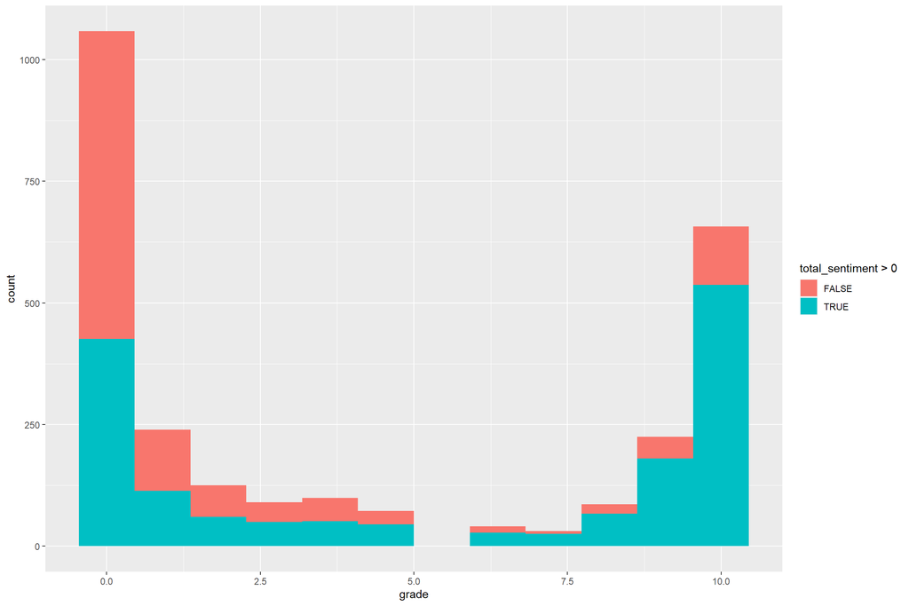

```r
user_w_sentiments %>%
  ggplot(aes(x = grade, fill = total_sentiment > 0)) + geom_histogram(bins = 12)
```

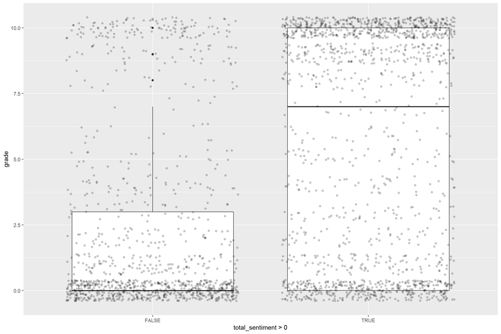

```r
user_w_sentiments %>%
  ggplot(aes(y = grade, x = total_sentiment > 0)) + geom_boxplot() +
  geom_jitter(alpha = 0.2)
```

```r
user_w_sentiments %>%
  summarize(sd = sd(grade) * 10,
            mean = mean(grade) * 10)
```

```
## # A tibble: 1 x 2
##      sd  mean
##   <dbl> <dbl>
## 1  43.2  41.4
```

A really extreme distribution, as I can tell. With a sd of 43.2! Remember the previous one was 6.23

Finally, let’s check out the *items* data. I’m interested in the *category* and in the *sell_value*

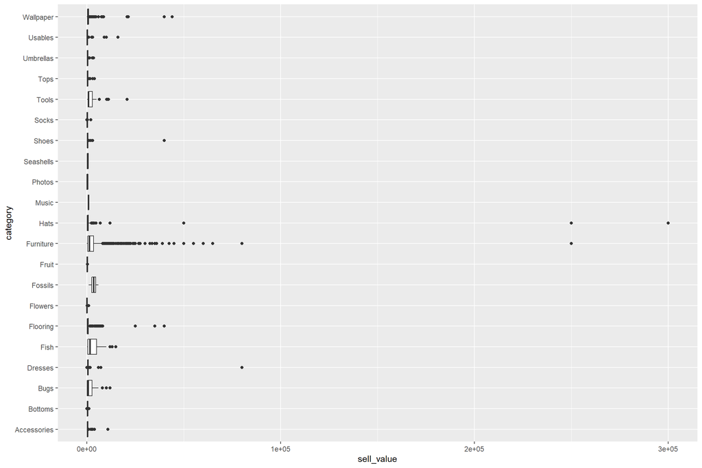

```r
items %>%
  mutate(sell_currency = replace_na(sell_currency, -1)) %>%
  filter(sell_currency >= 0) %>%
  ggplot(aes(x = category, y = sell_value)) + geom_boxplot() +
  coord_flip()
```

The boxplot went bananas. Let’s reflect that plotting the *sd*.

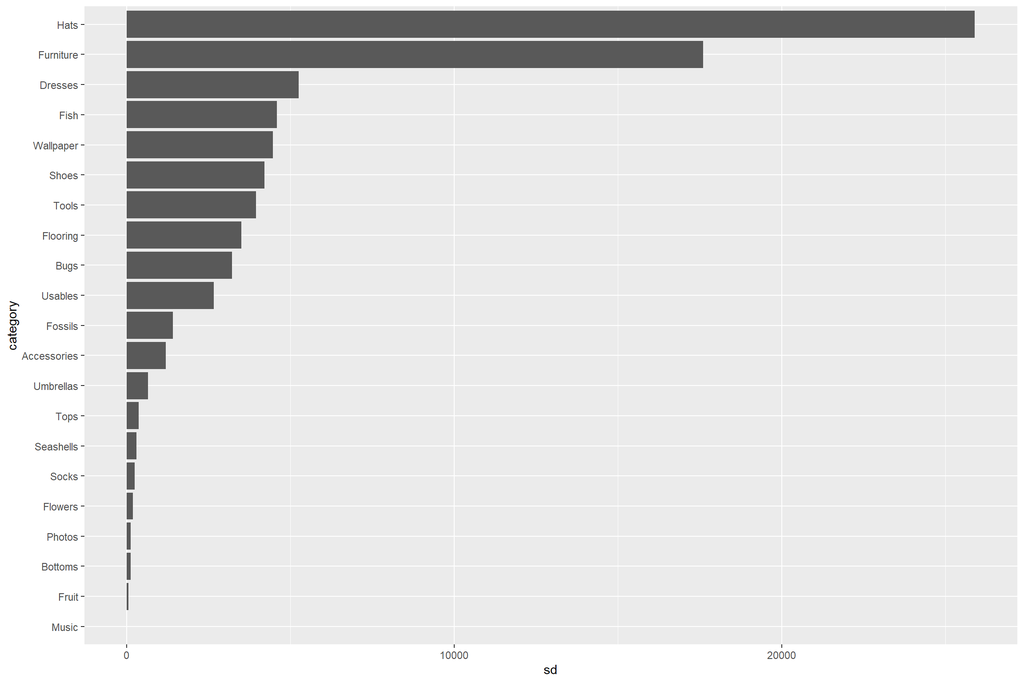

```r
items %>%
  group_by(category) %>%
  filter(!is.na(sell_value)) %>%
  summarize(sd = sd(sell_value)) %>%
  arrange(desc(sd)) %>%
  mutate(category = as_factor(category),
        category = fct_reorder(category, sd)) %>%
  ggplot(aes(x = category, y = sd)) + geom_col() + coord_flip()
```

In the game, it seems like there are rare items that are really expensive. In game data, those outliers are a common thing. There is an exponential growth on how much money can a player generate against time. So, let’s do a boxplot for two categories.

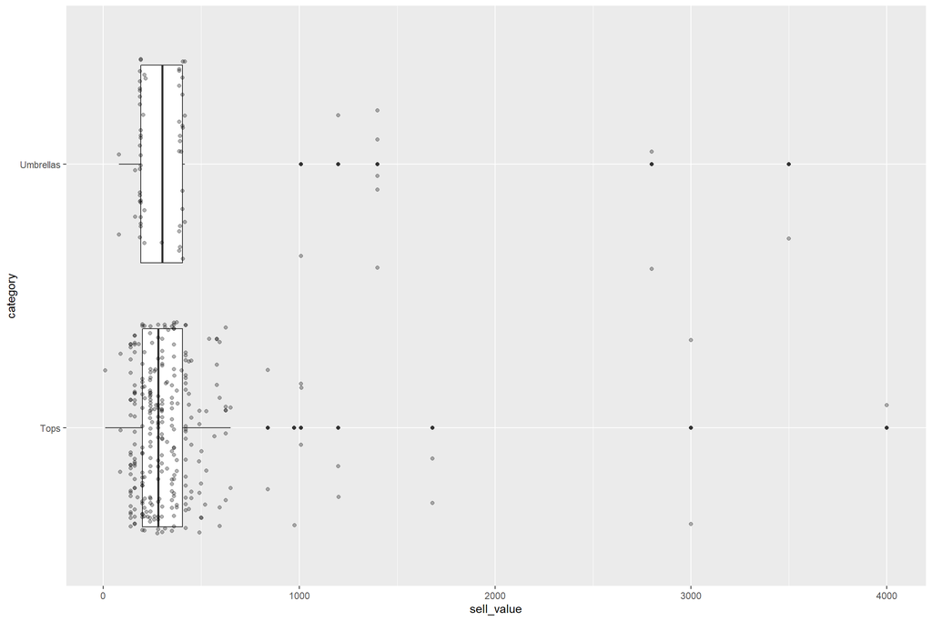

```r
items %>%
  mutate(sell_currency = replace_na(sell_currency, -1)) %>%
  filter(sell_currency >= 0,
         category %in% c("Umbrellas", "Tops")) %>%
  ggplot(aes(x = category, y = sell_value)) + geom_boxplot() +
  geom_jitter(alpha = 0.3) +
  coord_flip()
```

I have no more questions today, so my job here is done. Stay safe and thanks for reading!